# Portfolio Project

Kevin Chen

2023-06-15

## Introduction

#### Hello! Thank you for taking the time to view my portfolio, which also serves as my capstone project for the completion of the Google Data Analytics Professional Certificate. Since I aspire to work in the **healthcare industry**, I have chosen to address a relevant business task. In this portfolio I will assume the role of a data analyst at a prominent health insurance company.

#### The goals of this project are:

#### Solve a business task that is relevant in the healthcare industry

#### Use R Markdown to document each step of the data analysis process

#### Demonstrate my skills in spreadsheet, SQL, Tableau, Python, R, and R Markdown

## Table of Contents

### Step 1: Ask [Soft skills: Collaboration, etc]

##### 1a. Identify the business task

##### 1b. Consider key stakeholder

##### 1c. Choose a dataset

##### 1d. Establish metrics

##### 1e. Finalize the business task to investigate

### Step 2: Prepare [Skills: Spreadsheet, SQL]

##### 2a. Store Data appropriately

##### 2b. Identify how it’s organized

##### 2c. Sort and filter the data

##### 2d. Determine the credibility of the data

### Step 3: Process [Skills: Python, SQL, Spreadsheet]

##### 3a. Check the data for errors

##### 3b. Choose my tools

##### 3c. Document the cleaning process

### Step 4: Analyze [Skill: R]

##### 4a. Document calculations and analysis steps

##### 4b. Summary of my analysis

### Step 5: Share [Skill: Tableau]

##### 5a. Create effective data visualizations

##### 5b. Present my findings

### Step 6: Act [Skill: R Markdown]

##### 6a. My portfolio

##### 6b. Add this case study to portfolio

##### 6c. Top high-level insights based on my analysis

## Step 1: Ask

#### **Soft Skills: Collaboration, Active Listening, Critical Thinking, Data Collection, etc**

#### I was approached by my colleague, a customer experience manager, who expressed curiosity about understanding the potential impact of life satisfaction on the health outcomes. He posed the following question:

#### *“Is there a correlation between individuals’ sense of life satisfaction and their health outcomes?”*

### 1a. Identify the business task

#### My colleague’s question shows a general interest to explore and uncover valuable insights in the healthcare domain, however the question was too vague and it did not specify the exact analysis or methodology. In order to clarify the business task, I followed up by asking the following SMART questions:

#### (S)pecific:

##### *“Can you provide specific criteria for individuals’ sense of life satisfaction?”*

##### *“What specific health outcomes or metrics are we interested in examining in relation to life satisfaction?”*

#### (M)easureable:

##### *“How can we quantify and measure individuals’ sense of life satisfaction and health outcomes?”*

##### *“Can we establish a survey instrument to assess life satisfaction and health outcomes?”*

#### (A)ction-oriented:

##### *“In what ways can we tailor health insurance offerings or coverage options to better support individuals’ life satisfaction and positively impact their health outcomes??”*

##### *“What actions can we take to raise awareness and educate individuals about the importance of life satisfaction in achieving better health outcomes?”*

#### (R)elevant:

##### *“In what demographic groups are we interested in studying the correlation between life satisfaction and health outcomes?”*

##### *“How does understanding this correlation align with the goals and priorities of our company?”*

#### (T)ime-bound:

##### *“Within what timeframe do we aim to complete the analysis of the correlation between life satisfaction and health outcomes?”*

##### *“How far back in time should we analyze the data to capture a meaningful trend?”*

### 1b. Consider key stakeholder

#### Primary stakeholders:

##### Executive Management: Responsible for strategic decision-making, they utilize the correlation analysis to drive improvements in health insurance offerings and align company goals with the relationship between calmness, health outcomes, and satisfaction with healthcare services.

##### Product Development Manager: Utilizes correlation analysis insights to enhance health insurance products, incorporating coverage options addressing mental well-being and additional support services.

##### Marketing Manager: Develops targeted campaigns using correlation analysis findings to highlight the company’s commitment to holistic well-being and customer satisfaction.

##### Data Analyst: Conducts correlation analysis, providing insights on the relationship between calmness, health outcomes, and satisfaction with healthcare services, guiding decision-making processes.

##### Customer Experience Manager: Utilizes correlation analysis to identify areas for improvement, ensuring a seamless and satisfactory experience that considers the impact of calmness on health outcomes and satisfaction with healthcare services.

#### Secondary stakeholders:

##### Policyholders: Directly affected by the correlation between calmness, health outcomes, and satisfaction with healthcare services, potential improvements in coverage, access to care, and overall well-being support.

##### Customer Support Representatives: Implement improvements resulting from the correlation analysis, providing guidance on accessing mental health resources and explaining expanded coverage options to policyholders.

##### Claims Processing Team: Informed of changes resulting from the correlation analysis, ensuring accurate coverage assessment and seamless implementation for policyholders.

### 1c. Choose a dataset

#### Gallup World Poll - Public Sector

##### [Dataset Source: Global Wellbeing Initiative](https://www.gallup.com/analytics/318923/world-poll-public-datasets.aspx)

##### The Global Wellbeing Initiative (GWI) will generate an innovative research agenda aimed at improving societies, families and workplaces. This includes developing new models of wellbeing to reflect the impact of culture, community, governance and nature.

#### [**Click here to view the dataset!**](https://docs.google.com/spreadsheets/d/1obelPwGNgcZV46w2IHTHeK3k5GgcIibv/edit?usp=sharing&ouid=102598007405934795264&rtpof=true&sd=true)

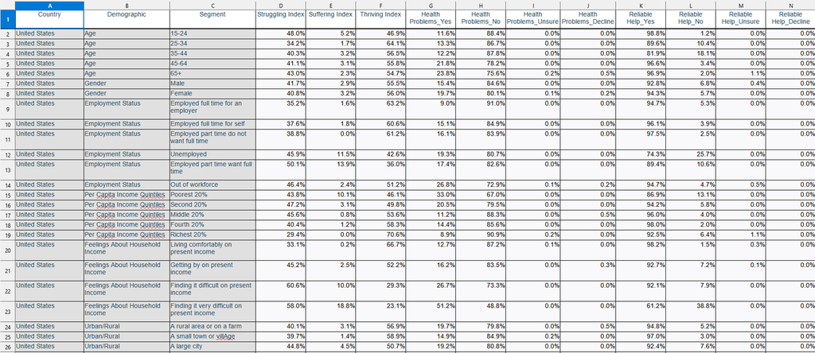

### 1d. Establish metrics

#### After engaging in a conversation with my colleague and carefully considering to his responses to the SMART questions, I assessed the data available in the dataset, resulting in the establishment of the following metrics:

##### Age

##### Calmness Index

##### Employment status

##### Job Satisfaction

##### Life at Peace

##### Gender

##### Health Problem Prevalence

##### Per capita income quintiles

##### Life in Balance

##### Urban/rural classification

### 1e. Finalize the business task to investigate

#### **Investigate the correlation between individuals’ health problem prevalence and their sense of life satisfaction, as indicated by the calmness index, feeling at peace with life, work-life balance, and enjoyment of work.**

## Step 2: Prepare

#### **Skills Demonstration: Spreadsheet, SQL**

### 2a. Store Data appropriately

#### My approach to store the dataset resonsibly involves two steps:

#### 1. I will maintain a local copy in a dedicated folder on my computer, allowing for easy access and efficient modifications during work-in-progress.

#### 2. During milestones or significant revisions, I will upload the revised view-only file to my Google Drive account. Google Drive provides dependable cloud storage, enabling seamless sharing with stakeholders.

#### By combining the convenience of local storage with the security and accessibility of cloud storage, I ensure responsible and efficient management of the dataset file.

### 2b. Identify how it’s organized

#### In terms of file organization, the following actions were taken:

#### A proper file naming convention was implemented, keeping the file name short with revision number included.

#### A logical folder structure was created with folders and subfolders to group related files.

#### Ongoing work was separated from finalized work, with ongoing work stored on the local computer and finalized work stored on Google Drive.

#### Regular manual backups of files were performed to prevent data loss.

### 2c. Sort and filter the data

#### In this initial phase of data exploration, I used SQL to list top 10 ranking in the Thriving Index, Struggling Index, and Suffering Index.

##### Average Thriving Index:

```
SELECT
  Country,
  CONCAT(CAST(AVG(Thriving_Index) * 100 AS INT64), "%") AS Average_Thriving_Index
FROM `quixotic-bonito-388417.Capstone.rev5`
GROUP BY Country
ORDER BY AVG(Thriving_Index) DESC
LIMIT 10;
```

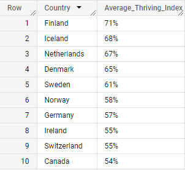

##### Average Struggling Index:

```
SELECT
  Country,
  CONCAT(CAST(AVG(Struggling_Index) * 100 AS INT64), "%") AS Average_Struggling_Index
FROM `quixotic-bonito-388417.Capstone.rev5`
GROUP BY Country
ORDER BY Average_Struggling_Index DESC
LIMIT 10;
```

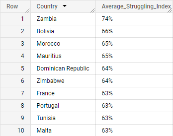

##### Average Suffering Index:

```
SELECT
  Country,
  CONCAT(CAST(AVG(Suffering_Index) * 100 AS INT64), "%") AS Average_Suffering_Index
FROM portfolio_project
GROUP BY Country
ORDER BY AVG(Suffering_Index) DESC;
```

[figure not shown]

### 2d. Determine the credibility of the data

#### The dataset utilized for this portfolio project originates from Gallup World Poll, a reputable source of second-party data. Gallup World Poll collects data on behalf of their clients, and this dataset is considered open data, accessible to the public, facilitating independent analysis and the generation of new insights. However, the specific time frame for data collection is not explicitly provided. Nevertheless, taking into account the available information, the source of this dataset is regarded as highly credible for the purposes of this project.

##### [Dataset Source: Global Wellbeing Initiative](https://www.gallup.com/analytics/318923/world-poll-public-datasets.aspx)

## Step 3: Process

#### **Skills Demonstration: Spreadsheet, SQL**

### 3a. Check the data for errors

#### The following factors were considered when checking the data for errors. For detailed documentation of the cleaning process, please refer to Section 3c.

#### **Inspect Data Quality**: Review the dataset to identify any obvious anomalies or inconsistencies, such as missing values, outliers, or unexpected data formats.

#### **Transform Data**: Perform necessary data transformations to address identified errors or inconsistencies. This may involve imputing missing values, converting data types, normalizing variables, or applying mathematical operations.

#### **Perform Data Cleaning**: Address any remaining errors or inconsistencies by cleaning the data. This may involve removing duplicates, correcting formatting issues, or applying other appropriate data cleaning techniques.

#### **Validate Data Integrity**: Check for data integrity issues, such as duplicate records or inconsistent data relationships, by comparing data across relevant variables or conducting data integrity checks.

#### **Document Data Issues**: Keep a record of identified data errors, their causes, and the steps taken to address them. This documentation helps in maintaining data quality and provides insights for future analysis.

### 3b. Choose my tools

#### Here are the tools I have chosen to perform the requirements listed in Section 3a.

#### **Inspect Data Quality**: Spreadsheet

#### **Data Transformation**: Judpyter Notebook (Python), BigQuery, Spreadsheet

#### **Data Cleaning**: Spreadsheet

#### **Validate Data Integrity**: Judpyter Notebook (Python), BigQuery

#### **Document Data Issues**: R Markdown

### 3c. Document the cleaning process

##### **01. Inspect Data Quality:** Downloaded original .xlsx file from the Gallup World Poll. Found merged cells that need to be addressed. [[Revision_01]](https://docs.google.com/spreadsheets/d/18NTWx58kWfN33_5pz1HYRQ7L6ZHAiICv/edit?usp=sharing&ouid=102598007405934795264&rtpof=true&sd=true)

##### **02. Data Transformation:** Manually merged both sheets in Revision_1 into one sheet. [[Revision_02]](https://docs.google.com/spreadsheets/d/1heaZYK7zmrFvijHA5R7JUhvxtdQ2TwWd/edit?usp=sharing&ouid=102598007405934795264&rtpof=true&sd=true)

##### **03. Data Transformation:** Unmerge cells in Column A and Column B, then manually replace the missing values. [[Revision_03]](https://docs.google.com/spreadsheets/d/1BvXG1epRRbNGj6LOWYcWVfJeb3t48Raq/edit?usp=sharing&ouid=102598007405934795264&rtpof=true&sd=true)

##### **04. Data Transformation:** Used *spreadsheet* function `=CONCATENATE(G3, ": ", G4)` to create informative column names. [[Revision_04]](https://docs.google.com/spreadsheets/d/1JpqImPD0biu172rn3QgjUeqjdjMscUl_/edit?usp=sharing&ouid=102598007405934795264&rtpof=true&sd=true)

##### **05. Data Cleaning:** Remove redundant rows from Revision_4. Row 2, 5 removed. [[Revision_05]](https://docs.google.com/spreadsheets/d/1us6Q9AwWuglFYxzzp3Wggmg6GnT5qDNN/edit?usp=sharing&ouid=102598007405934795264&rtpof=true&sd=true)

##### **06. Data Cleaning:** Used *spreadsheet* function `=LOWER(SUBSTITUTE(A2, " ", "_"))` to standardize columns names. [[Revision_06]](https://docs.google.com/spreadsheets/d/1obelPwGNgcZV46w2IHTHeK3k5GgcIibv/edit?usp=sharing&ouid=102598007405934795264&rtpof=true&sd=true)

##### **07. Data Transformation:** Below *SQL* ROW_NUMBER function was successfully executed to create a ‘row_number’ column and sort the dataset by the ‘country’ and ‘demographic’ columns. [[Revision_07]](https://docs.google.com/spreadsheets/d/1cUHJLjC9nPWZ853D9v-PyyVhJAljecLu/edit?usp=sharing&ouid=102598007405934795264&rtpof=true&sd=true)

```
SELECT
  ROW_NUMBER() OVER (ORDER BY country, demographic) AS row_number,
  *
FROM `quixotic-bonito-388417.Capstone.rev6`
```

##### **08. Data Transformation:** Below *Python* code executed successfully, Concatenate 3 columns to create a ‘primary_key’ column. [[Revision_08]](https://docs.google.com/spreadsheets/d/1tF0FsLQErKrUGB7unhabsdHT56ThkGoh/edit?usp=sharing&ouid=102598007405934795264&rtpof=true&sd=true)

```
portfolio_df['primary_key'] = portfolio_df['country'] + '_' + portfolio_df['demographic'] + '_' + portfolio_df['segment']
```

##### **09. Data Quality Inspection:** Below *Python* code execuded successfully, verified there are no duplicate entries.

```
duplicates = portfolio_df.duplicated(subset='primary_key')

if duplicates.any():
    duplicate_rows = df[duplicates]
    print("Duplicate rows based on 'primary_key' column:")
    print(duplicate_rows)
else:
    print("No duplicate values found in the 'primary_key' column.")
```

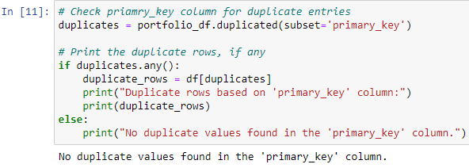

##### **10a. Validate Data Integrity:** Below *Python* code executed successfully, verified 0% missing values for all columns.

```
for col in portfolio_df.columns:
    pct_missing = np.mean(portfolio_df[col].isnull())
    print('{} - {}%'.format(col, round(pct_missing*100)))
```

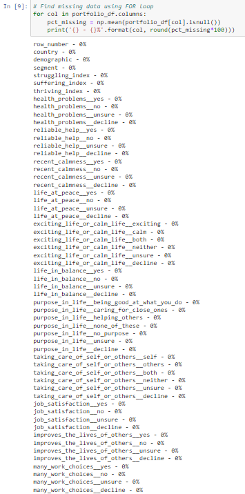

##### **10b. Validate Data Integrity:** Below *Python* code executed successfully, a closer look to confirm all columns has 0 missing values.

```
print(portfolio_df.isnull().sum())
```

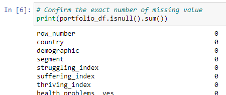

##### **11. Validate Data Integrity:** Below *Python* code executed successfully to verify all column data types are correct.

```
print(portfolio_df.dtypes)
```

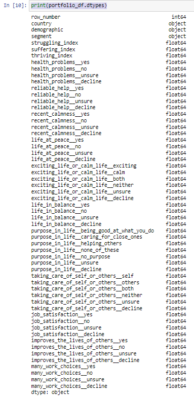

##### **12. Data Transformation:** Manually divided the ‘segment’ column into six new columns, each representing a distinct demographic segment. [[Revision_09]](https://docs.google.com/spreadsheets/d/1iQrkkrIcG8c3a43WWUwx_h4FKf6WgW7J/edit?usp=sharing&ouid=102598007405934795264&rtpof=true&sd=true)

## Step 4: Analyze

#### **Skill Demonstration: R**

### 4a. Document calculations and analysis steps

#### 1: Load packages and libraries

```
install.packages("tidyverse")
install.packages("tidyr")
install.packages("dplyr")
install.packages("plyr")
install.packages("knitr")

library(tidyverse)
library(tidyr)
library(dplyr)
library(plyr)
library(knitr)
```

#### 2: Import dataset

```
portfolio_df <- read_xlsx("Rev08_Portfolio_Project.xlsx")
```

#### 3: Data exploration

```
colnames(portfolio_df)
str(portfolio_df)
glimpse(portfolio_df)
head(portfolio_df)
skim_without_charts(portfolio_df)
```

#### 4: Count of participating countries.

##### output: There are 51 participating countries

```
country_counts <- portfolio_df %>%
  filter(country != 'Global') %>%
  distinct(country) %>%
  summarize(count = n_distinct(country))

print(country_counts)
```

#### 5: Summarize “health problems” vs “age”

```
health_problem_age_15to24 <- portfolio_df %>%
  filter(segment == '15-24' & country != 'Global') %>%
  mutate(health_problems__yes = as.numeric(health_problems__yes)) %>%
 summarise(health_problem_age1 = mean(health_problems__yes, na.rm = TRUE))

health_problem_age_25to34 <- portfolio_df %>%
  filter(segment == '25-34' & country != 'Global') %>%
  mutate(health_problems__yes = as.numeric(health_problems__yes)) %>%
  summarise(health_problem_age2 = mean(health_problems__yes, na.rm = TRUE))

health_problem_age_35to44 <- portfolio_df %>%
  filter(segment == '35-44' & country != 'Global') %>%
  mutate(health_problems__yes = as.numeric(health_problems__yes)) %>%
  summarise(health_problem_age3 = mean(health_problems__yes, na.rm = TRUE))

health_problem_age_45to64 <- portfolio_df %>%
  filter(segment == '45-64' & country != 'Global') %>%
  mutate(health_problems__yes = as.numeric(health_problems__yes)) %>%
  summarise(health_problem_age4 = mean(health_problems__yes, na.rm = TRUE))

health_problem_age_over65 <- portfolio_df %>%
  filter(segment == '65+' & country != 'Global') %>%
  mutate(health_problems__yes = as.numeric(health_problems__yes)) %>%
  summarise(health_problem_age5 = mean(health_problems__yes, na.rm = TRUE))

print(sprintf("%.2f%%", health_problem_age_15to24 * 100))
print(sprintf("%.2f%%", health_problem_age_25to34 * 100))
print(sprintf("%.2f%%", health_problem_age_35to44 * 100))
print(sprintf("%.2f%%", health_problem_age_45to64 * 100))
print(sprintf("%.2f%%", health_problem_age_over65 * 100))
```

##### Output:

###### 9.30% of Age 15-24 have health problems

###### 10.72% of Age 25-34 have health problems

###### 15.41% of Age 35-44 have health problems

###### 27.85% of Age 45-64 have health problems

###### 42.58% of Age 65+ have health problems

#### 6: Summarize “health problems” vs “employment status”

```
health_problem_employed_for_employer <- portfolio_df %>%
  filter(segment == 'Employed full time for an employer' & country != 'Global') %>%
  mutate(health_problems__yes = as.numeric(health_problems__yes)) %>%
  summarise(health_problem_employment1 = mean(health_problems__yes, na.rm = TRUE))

health_problem_employed_for_self <- portfolio_df %>%
  filter(segment == 'Employed full time for self' & country != 'Global') %>%
  mutate(health_problems__yes = as.numeric(health_problems__yes)) %>%
  summarise(health_problem_employment2 = mean(health_problems__yes, na.rm = TRUE))

health_problem_parttime_refuse_fulltime <- portfolio_df %>%
  filter(segment == 'Employed part time do not want full time' & country != 'Global') %>%
  mutate(health_problems__yes = as.numeric(health_problems__yes)) %>%
  summarise(health_problem_employment3 = mean(health_problems__yes, na.rm = TRUE))

health_problem_parttime_want_fulltime <- portfolio_df %>%
  filter(segment == 'Employed part time want full time' & country != 'Global') %>%
  mutate(health_problems__yes = as.numeric(health_problems__yes)) %>%
  summarise(health_problem_employment5 = mean(health_problems__yes, na.rm = TRUE))

health_problem_Unemployed <- portfolio_df %>%
  filter(segment == 'Unemployed' & country != 'Global') %>%
  mutate(health_problems__yes = as.numeric(health_problems__yes)) %>%
  summarise(health_problem_employment4 = mean(health_problems__yes, na.rm = TRUE))

health_problem_Out_of_workforce <- portfolio_df %>%
  filter(segment == 'Out of workforce' & country != 'Global') %>%
  mutate(health_problems__yes = as.numeric(health_problems__yes)) %>%
  summarise(health_problem_employment6 = mean(health_problems__yes, na.rm = TRUE))

print(sprintf("%.2f%%", health_problem_employed_for_employer * 100))
print(sprintf("%.2f%%", health_problem_employed_for_self * 100))
print(sprintf("%.2f%%", health_problem_parttime_refuse_fulltime * 100))
print(sprintf("%.2f%%", health_problem_parttime_want_fulltime * 100))
print(sprintf("%.2f%%", health_problem_Unemployed * 100))
print(sprintf("%.2f%%", health_problem_Out_of_workforce * 100))
```

##### Output:

###### 12.13% of ‘Employed full time for an employer’ have health problems

###### 15.06% of ‘Employed full time for self’ have health problems

###### 18.82% of ‘Employed part time do not want full time’ have health problems

###### 20.02% of ‘Employed part time want full time’ have health problems

###### 18.49% of ‘Unemployed’ have health problems

###### 31.04% of ‘Out of workforce’ have health problems

#### 7: Summarize “health problems” vs “gender”

```
health_problem_male <- portfolio_df %>%
  filter(segment == 'Male' & country != 'Global') %>%
  mutate(health_problems__yes = as.numeric(health_problems__yes)) %>%
  summarise(health_problem_employment1 = mean(health_problems__yes, na.rm = TRUE))

health_problem_female <- portfolio_df %>%
  filter(segment == 'Female' & country != 'Global') %>%
  mutate(health_problems__yes = as.numeric(health_problems__yes)) %>%
  summarise(health_problem_employment1 = mean(health_problems__yes, na.rm = TRUE))

print(sprintf("%.2f%%", health_problem_male * 100))
print(sprintf("%.2f%%", health_problem_female * 100))
```

##### output:

###### 17.76% of ‘Male’ have health problems

###### 23.54% of ‘Female’ have health problems

#### 8: Summarize “health problems” vs “Per Capita Income Quintiles”

```
health_problem_poorest_20 <- portfolio_df %>%
  filter(segment == 'Poorest 20%' & country != 'Global') %>%
  mutate(health_problems__yes = as.numeric(health_problems__yes)) %>%
  summarise(health_problem_employment1 = mean(health_problems__yes, na.rm = TRUE))

health_problem_second_20 <- portfolio_df %>%
  filter(segment == 'Second 20%' & country != 'Global') %>%
  mutate(health_problems__yes = as.numeric(health_problems__yes)) %>%
  summarise(health_problem_employment1 = mean(health_problems__yes, na.rm = TRUE))

health_problem_middle_20 <- portfolio_df %>%
  filter(segment == 'Middle 20%' & country != 'Global') %>%
  mutate(health_problems__yes = as.numeric(health_problems__yes)) %>%
  summarise(health_problem_employment1 = mean(health_problems__yes, na.rm = TRUE))

health_problem_fourth_20 <- portfolio_df %>%
  filter(segment == 'Fourth 20%' & country != 'Global') %>%
  mutate(health_problems__yes = as.numeric(health_problems__yes)) %>%
  summarise(health_problem_employment1 = mean(health_problems__yes, na.rm = TRUE))

health_problem_richest_20 <- portfolio_df %>%
  filter(segment == 'Richest 20%' & country != 'Global') %>%
  mutate(health_problems__yes = as.numeric(health_problems__yes)) %>%
  summarise(health_problem_employment1 = mean(health_problems__yes, na.rm = TRUE))

print(sprintf("%.2f%%", health_problem_poorest_20 * 100))
print(sprintf("%.2f%%", health_problem_second_20 * 100))
print(sprintf("%.2f%%", health_problem_middle_20 * 100))
print(sprintf("%.2f%%", health_problem_fourth_20 * 100))
print(sprintf("%.2f%%", health_problem_richest_20 * 100))
```

##### output:

###### 26.61% of ‘Poorest 20%’ have health problems

###### 24.11% of ‘Second 20%’ have health problems

###### 20.25% of ‘Middle 20%’ have health problems

###### 17.92% of ‘Fourth 20%’ have health problems

###### 14.54% of ‘Richest 20%’ have health problems

#### 9: Summarize “health problems” vs “Urban/Rural”

```
health_problem_rural <- portfolio_df %>%
  filter(segment == 'A rural area or on a farm' & country != 'Global') %>%
  mutate(health_problems__yes = as.numeric(health_problems__yes)) %>%
  summarise(health_problem_employment1 = mean(health_problems__yes, na.rm = TRUE))

health_problem_town <- portfolio_df %>%
  filter(segment == 'A small town or villAge' & country != 'Global') %>%
  mutate(health_problems__yes = as.numeric(health_problems__yes)) %>%
  summarise(health_problem_employment1 = mean(health_problems__yes, na.rm = TRUE))

health_problem_city <- portfolio_df %>%
  filter(segment == 'A large city' & country != 'Global') %>%
  mutate(health_problems__yes = as.numeric(health_problems__yes)) %>%
  summarise(health_problem_employment1 = mean(health_problems__yes, na.rm = TRUE))

health_problem_suburb <- portfolio_df %>%
  filter(segment == 'A suburb of a large city' & country != 'Global') %>%
  mutate(health_problems__yes = as.numeric(health_problems__yes)) %>%
  summarise(health_problem_employment1 = mean(health_problems__yes, na.rm = TRUE))

print(sprintf("%.2f%%", health_problem_rural * 100))
print(sprintf("%.2f%%", health_problem_town * 100))
print(sprintf("%.2f%%", health_problem_city * 100))
print(sprintf("%.2f%%", health_problem_suburb * 100))
```

##### output:

###### 23.38% of ‘A rural area or on a farm’ have health problems

###### 21.79% of ‘A small town or villAge’ have health problems

###### 17.94% of ‘A large city’ have health problems

###### 19.73% of ‘A suburb of a large city’ have health problems

#### 10: Investigating correlation: “Health Problem” and “Recent Calmness”

```
correlation_health_calmness_yes <- portfolio_df %>%
  filter(country != 'Global') %>%
  select(health_problems__yes, recent_calmness__yes) %>%
  cor()

correlation_health_calmness_no <- portfolio_df %>%
  filter(country != 'Global') %>%
  select(health_problems__yes, recent_calmness__no) %>%
  cor()

print(correlation_health_calmness_yes)
print(correlation_health_calmness_no)
```

##### output:

###### The correlation coefficient of -0.0295 indicates a weak negative correlation between health problems and having recently felt calmness.

###### The correlation coefficient of 0.053 indicates a weak positive correlation between health problems and **not** having recently felt calmness.

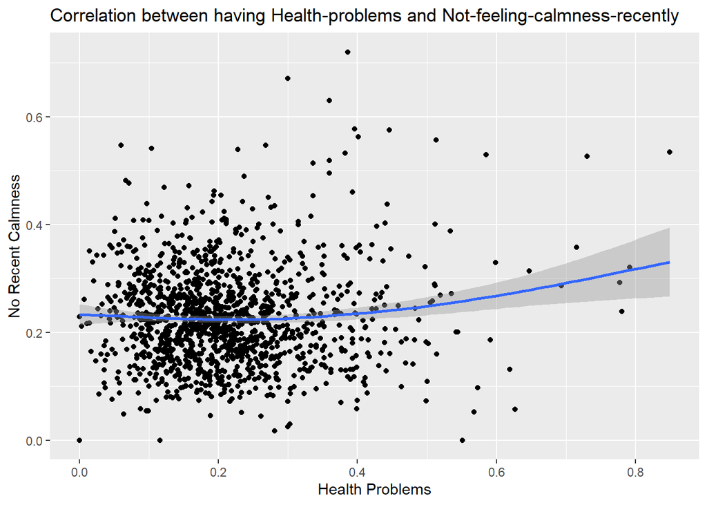

```r
ggplot(portfolio_df) +
  geom_point(mapping = aes(x = health_problems__yes, y = recent_calmness__no)) +
  geom_smooth(mapping = aes(x = health_problems__yes, y = recent_calmness__no)) +
  labs(x = "Health Problems", y = "No Recent Calmness") +
  ggtitle("Correlation between having Health-problems and Not-feeling-calmness-recently")
```

#### 11: Investigating correlation: “Health Problem” and “Life at Peace”

```
correlation_health_life_at_peace_yes <- portfolio_df %>%
  filter(country != 'Global') %>%
  select(health_problems__yes, life_at_peace__yes) %>%
  cor()

correlation_health_life_at_peace_no <- portfolio_df %>%
  filter(country != 'Global') %>%
  select(health_problems__yes, life_at_peace__no) %>%
  cor()

print(correlation_health_life_at_peace_yes)
print(correlation_health_life_at_peace_no)
```

##### output:

###### The correlation coefficient of -0.2867 indicates a weak negative correlation between health problems and feeling life is at peace.

###### The correlation coefficient of 0.3101 indicates a weak positive correlation between health problems and feeling life is **not** at peace.

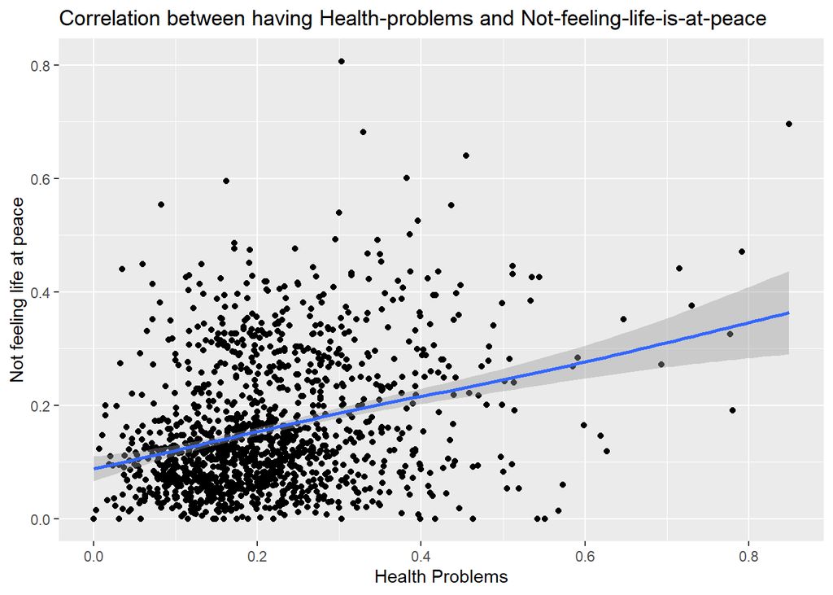

```r
ggplot(portfolio_df) +
  geom_point(mapping = aes(x = health_problems__yes, y = life_at_peace__no)) +
  geom_smooth(mapping = aes(x = health_problems__yes, y = life_at_peace__no)) +
  labs(x = "Health Problems", y = "Not feeling life at peace") +
  ggtitle("Correlation between having Health-problems and Not-feeling-life-is-at-peace")
```

#### 12: Investigating correlation: “Health Problem” and “Work-Life Balance”

```
correlation_health_life_in_balance_yes <- portfolio_df %>%
  filter(country != 'Global') %>%
  select(health_problems__yes, life_in_balance__yes) %>%
  cor()

correlation_health_life_in_balance_no <- portfolio_df %>%
  filter(country != 'Global') %>%
  select(health_problems__yes, life_in_balance__no) %>%
  cor()

print(correlation_health_life_in_balance_yes)
print(correlation_health_life_in_balance_no)
```

##### output:

###### The correlation coefficient of -0.2457 indicates a weak negative correlation between health problems and feeling work-life is in balance.

###### The correlation coefficient of 0.2266 indicates a weak positive correlation between health problems and feeling work-life is **not** in balance.

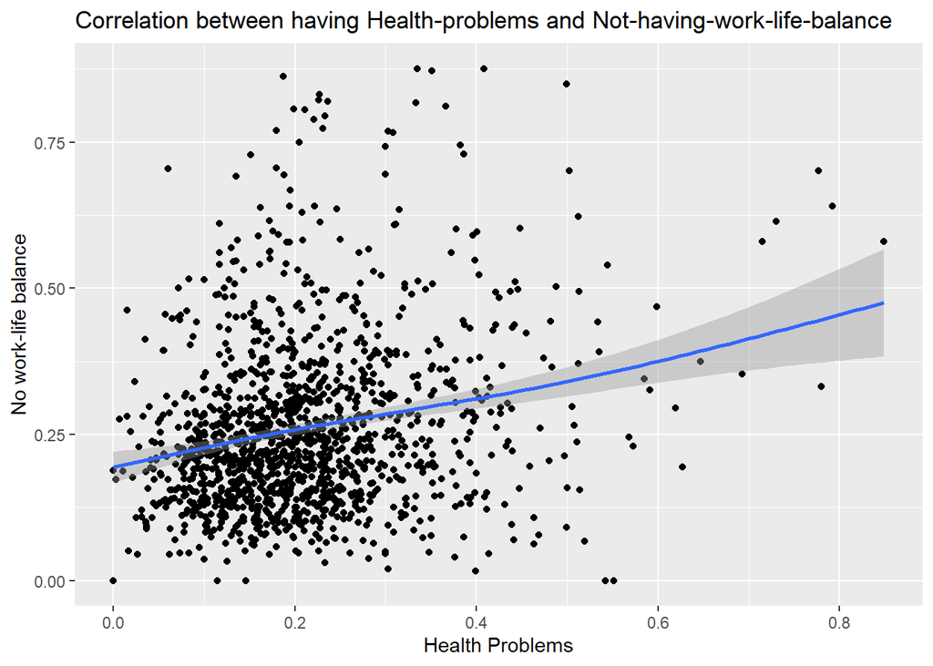

```r
ggplot(portfolio_df) +
  geom_point(mapping = aes(x = health_problems__yes, y = life_in_balance__no)) +
  geom_smooth(mapping = aes(x = health_problems__yes, y = life_in_balance__no)) +
  labs(x = "Health Problems", y = "No work-life balance") +
  ggtitle("Correlation between having Health-problems and Not-having-work-life-balance")
```

#### 13: Investigating correlation: “Health Problem” and “Job Satisfaction”

```
correlation_health_job_satisfaction_yes <- portfolio_df %>%
  filter(country != 'Global') %>%
  select(health_problems__yes, job_satisfaction__yes) %>%
  cor()

correlation_health_job_satisfaction_no <- portfolio_df %>%
  filter(country != 'Global') %>%
  select(health_problems__yes, job_satisfaction__no) %>%
  cor()

print(correlation_health_job_satisfaction_yes)
print(correlation_health_job_satisfaction_no)
```

##### output:

###### The correlation coefficient of -0.1184 indicates a weak negative correlation between health problems and having job satisfaction.

###### The correlation coefficient of 0.032 indicates a weak positive correlation between health problems and **not** having job satisfaction.

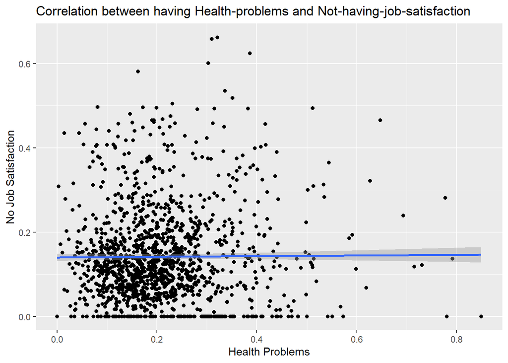

```r
ggplot(portfolio_df) +
  geom_point(mapping = aes(x = health_problems__yes, y = job_satisfaction__no)) +
  geom_smooth(mapping = aes(x = health_problems__yes, y = job_satisfaction__no)) +
  labs(x = "Health Problems", y = "No Job Satisfaction") +
  ggtitle("Correlation between having Health-problems and Not-having-job-satisfaction")
```

## Step 5: Share

#### **Skill Demonstration: Tableau**

### 5a. Create effective data visualizations

#### [[Click here to interact in Tableau]](https://public.tableau.com/app/profile/kevch27/viz/8_Portfolio-Project/PortfolioProject?publish=yes)

[figure not shown]

## Step 6: Act

#### **Skill Demonstration: R Markdown, Maven Analytics**

### 6a. My portfolio

#### My current portfolio is hosted on GitHub and Tableau Public. Please visit the links below for more of my skill demonstrations in SQL, Python, and Tableau!

#### 1. [[Tableau demonstration on Tableau Public]](https://public.tableau.com/app/profile/kevch27)

#### 2. [[SQL & Python demonstration on github]](https://github.com/kevch27/Portfolio_KC.git)

### 6b. Add this case study to portfolio

#### I have created a dedicated website at Maven Analytics to showcase this portfolio project. I have also added the associated documents to github.

#### 1. [[See this project on Maven Analytics]](https://mavenanalytics.io/project/6664)

#### 2. [[Tableau dashboard from this project added to Tableau Public]](https://public.tableau.com/app/profile/kevch27/viz/8_Portfolio-Project/PortfolioProject?publish=yes)

#### 3. [[The following documents from this project has been added to github:]](https://github.com/kevch27/Capstone.git)

#### Python Codes

#### R Codes

#### R Markdown

#### .html output

### 6c. Top high-level insights based on my analysis

#### However, to gain a more comprehensive understanding of the relationship between health problems and life satisfaction, further analysis and exploration are recommended. Factors such as education level, marital status, access to healthcare, and other potential influences should be investigated. Overall, the findings suggest the complex nature of the relationship between health problems and life satisfaction, emphasizing the need for in-depth exploration to inform decision-making and interventions related to well-being.